# Titanic

M Hassan

Monday, November 02, 2015

```r
trainData <- read.csv("train.csv", header = TRUE, stringsAsFactors = FALSE)
testData <- read.csv("test.csv", header = TRUE, stringsAsFactors = FALSE)
```

#### Exploring data

```r
head(trainData)
```

```
##   PassengerId Survived Pclass
## 1           1        0      3
## 2           2        1      1
## 3           3        1      3
## 4           4        1      1
## 5           5        0      3
## 6           6        0      3
##                                                  Name    Sex Age SibSp
## 1                             Braund, Mr. Owen Harris   male  22     1
## 2 Cumings, Mrs. John Bradley (Florence Briggs Thayer) female  38     1
## 3                              Heikkinen, Miss. Laina female  26     0
## 4        Futrelle, Mrs. Jacques Heath (Lily May Peel) female  35     1
## 5                            Allen, Mr. William Henry   male  35     0
## 6                                    Moran, Mr. James   male  NA     0
##   Parch           Ticket    Fare Cabin Embarked
## 1     0        A/5 21171  7.2500              S
## 2     0         PC 17599 71.2833   C85        C
## 3     0 STON/O2. 3101282  7.9250              S
## 4     0           113803 53.1000  C123        S
## 5     0           373450  8.0500              S
## 6     0           330877  8.4583              Q
```

#### Making basic visualizations

We’ll also take a look at a few values and plots to get a better understanding of our data. We start with a few simple generic x-y plots to get a feel. By first plotting the density we’re able to get a sense of how the overall data feel and get a few vague answers: where is the general center? Is there a skew? Does is generally take higher values? Where are most of the values concentrated?

```r
# summary of age distribution
summary(trainData$Age)
```

```
##    Min. 1st Qu.  Median    Mean 3rd Qu.    Max.    NA's
##    0.42   20.12   28.00   29.70   38.00   80.00     177
```

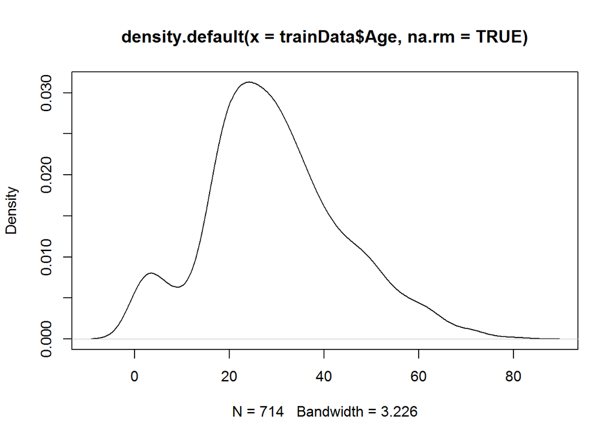

```r
plot(density(trainData$Age, na.rm = TRUE))
```

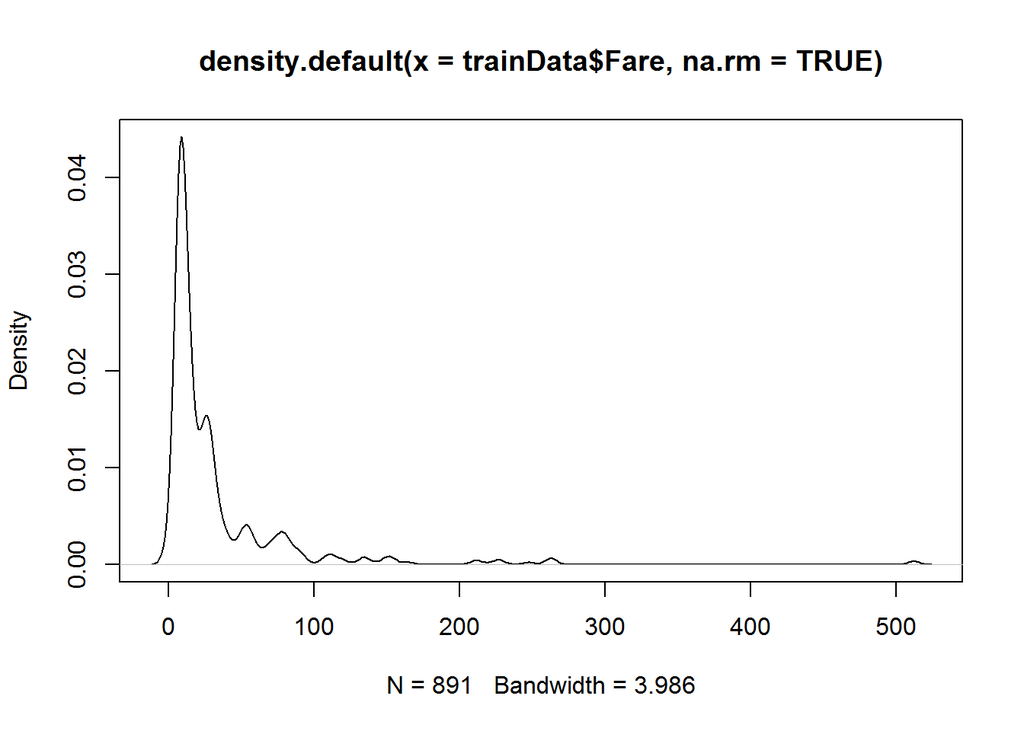

```r
plot(density(trainData$Fare, na.rm = TRUE))
```

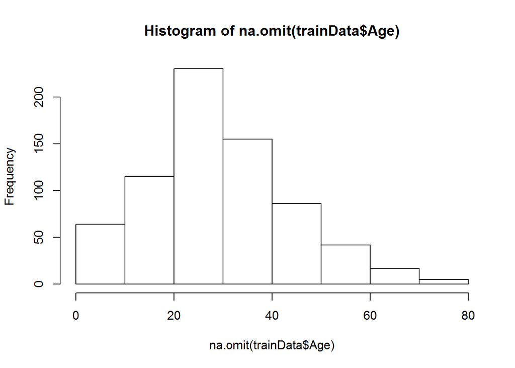

```r
hist(na.omit(trainData$Age))
```

Distributuion of Age per class

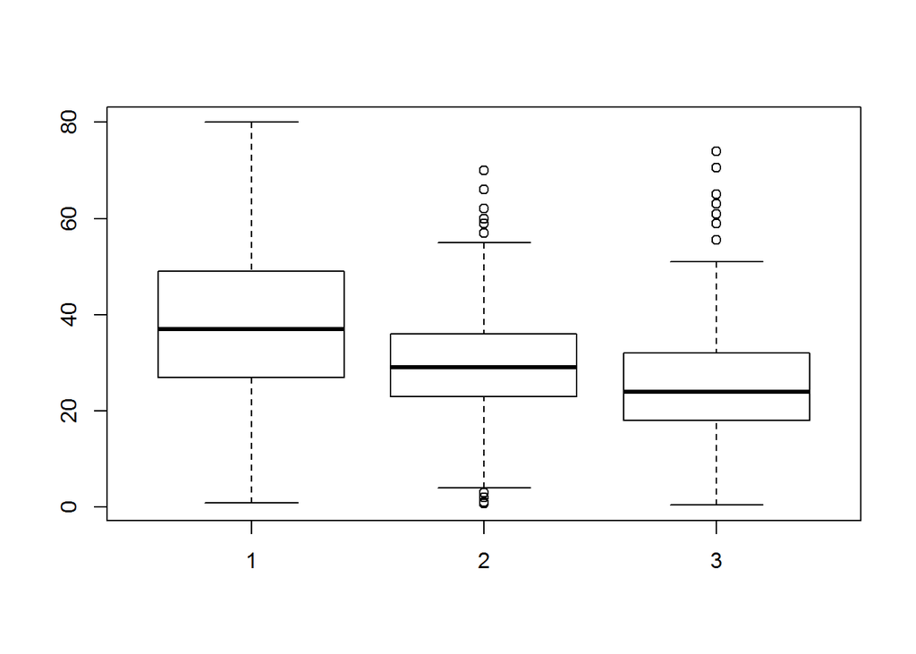

```r
boxplot(trainData$Age ~ trainData$Pclass)
```

The median for class 1 passengers is the highest. While class 3 passengers were the smallest. This tell us that the older passengers were most likely in a higher class cabin.

#### Survival rate by Sex Barplot

Lets now look at the survival rate filtered by sex. Our intuition is that women had a higher chance of surviving because the crewman used the standard “Women and Children first” to board the lifeboats. We first create a table and call it counts. Then we use R’s barplot() function with respective x-axis, y-axis, and main titles. We also calculate the male/female survival rates from the table by indexing the table we made called counts. counts[1] returns the top left value of the table, counts[2] the bottom left, and so on.

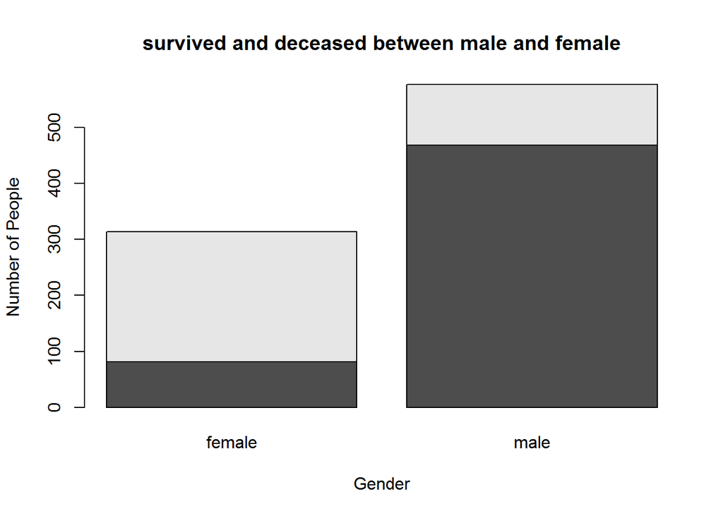

```r
counts <- table(trainData$Survived, trainData$Sex)
barplot(counts, xlab = "Gender", ylab = "Number of People", main = "survived and deceased between male and female")
```

```r
counts[2] / (counts[1] + counts[2])
```

```
## [1] 0.7420382
```

```r
counts[4] / (counts[3] + counts[4])
```

```
## [1] 0.1889081
```

Note that in the barplot you create the lighter areas indicate survival. Doing the calculations below the barplot we see that in our Train data, 74.2% of women survived versus 18.9% of men.

#### Survival Rate by Passenger Class Barplot

Lets now look at the survival rate filtered by passenger class.

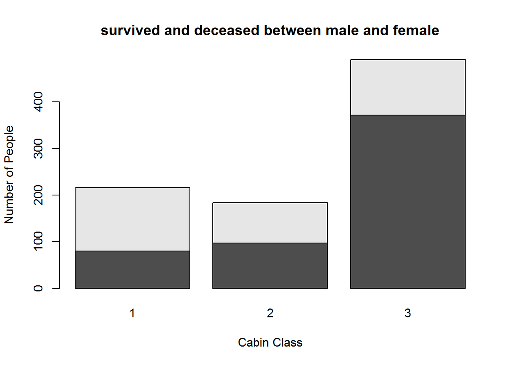

```r
Pclass_survival <- table(trainData$Survived, trainData$Pclass)
barplot(Pclass_survival, xlab = "Cabin Class", ylab = "Number of People",
main = "survived and deceased between male and female")
```

```r
Pclass_survival[2] / (Pclass_survival[1] + Pclass_survival[2])
```

```
## [1] 0.6296296
```

```r
Pclass_survival[4] / (Pclass_survival[3] + Pclass_survival[4])
```

```
## [1] 0.4728261
```

```r
Pclass_survival[6] / (Pclass_survival[5] + Pclass_survival[6])
```

```
## [1] 0.2423625
```

It seems like the Pclass column might also be informative in survival prediction as the survival rate of the 1st class, 2nd class, and 3rd class are: 63.0%, 47.3%, and 24.2% respectively.

Though not covered, a few more insights would be useful here; survival rate based on fare rages, survival rate based on age ranges etc. The key idea is that we’re trying to determine if any/which of our variables are related to what we’re trying to predict: Survived

#### Cleaning up the Train Data

After doing some exploratoy analysis of the data, we need to clean it to create our mdel. Note that it is important to explore the data so that understand what elements need to be cleaned. For example you might have noticed that there are missing values in the data, especially in Age column..

#### Removing variables not used for the model

At this point, we remove the variables that we don’t want to use in the training data for the model: PassengerID, Ticket, Fare, Cabin and Embarked. To do so,we index our data trainData with [ ]. The c() function generates a list of numbers. By including this list (along with a negative sign), we let R know to subset (or remove) those columns.

```r
trainData <- trainData[-c(1,9:12)]
```

#### Replacing Gender variable (Male/Female) with a Dummy Variable (0/1)

Additionally, we need to replace qualitative variables (such as gender) into quantitative variables (0 for male, 1 for female etc) in order to fit our model. Note that there are models where the variables can be qualitative. We use the R function gsub() which will replace any text with a value of our choosing.

```r
trainData$Sex = gsub("female", 1, trainData$Sex)
# ^male means string that starts with m
trainData$Sex = gsub("^male", 0, trainData$Sex)
```

##### Making Inferences on Missing Age Values

Lastly, upon examining our dataset, we see that many entries for “age” are missing. Because age entries could be an important variable we try inferencing them based on a relationship between title and age; we’re essentially assuming that Mrs.X will older than Ms.X. Moreover, we’re (naively) assuming that people with the same titles are closer together in age.

So first, we put the index of people with the specified surname into a list for further processing. In R we use the grep() function which will return a vector of row numbers which have a specified surname.

```r
master_vector = grep("Master.",trainData$Name, fixed=TRUE)
miss_vector = grep("Miss.", trainData$Name, fixed=TRUE)
mrs_vector = grep("Mrs.", trainData$Name, fixed=TRUE)
mr_vector = grep("Mr.", trainData$Name, fixed=TRUE)
dr_vector = grep("Dr.", trainData$Name, fixed=TRUE)
```

You might have noticed that there are other less frequent titles such as Reverend or Colonel which we are ignoring for now.

Next, we rename each name with a shortened tag. This means replacing the full name of an individual, such as “Allison, Master. Hudson Trevor” we shorten it to be “Master”. This allows for a standardized column This is done in the following.

```r
trainData$Name[master_vector] = 'Master'
trainData$Name[miss_vector] = 'Miss'
trainData$Name[mrs_vector] = 'Mrs'
trainData$Name[mr_vector] = 'Mr'
trainData$Name[dr_vector] = 'Dr'
```

Now that we have a series of standardized titles, we calculate the average age of each title.

#### Making Inference on Missing Age Values: Inputting Title-group averages

We replace the missing ages with their respective title-group average. This means that if we have a missing age entry for a man named Mr. Bond, we substitute his age for the average age for all passenger with the title Mr. Similarly for Master, Miss, Mrs, and Dr. We then write a for loop that goes through the entire Train data set and checks if the age value is missing. If it is, we assign it according to the surname of the observation. This code snippet is a bit complicated; you can just copy and paste for now if you’re not confident about understanding it!

```r
master_age = round(mean(trainData$Age[trainData$Name == "Master"], na.rm = TRUE), digits = 2)
miss_age = round(mean(trainData$Age[trainData$Name == "Miss"], na.rm = TRUE), digits =2)
mrs_age = round(mean(trainData$Age[trainData$Name == "Mrs"], na.rm = TRUE), digits = 2)
mr_age = round(mean(trainData$Age[trainData$Name == "Mr"], na.rm = TRUE), digits = 2)
dr_age = round(mean(trainData$Age[trainData$Name == "Dr"], na.rm = TRUE), digits = 2)
```

```r
for (i in 1:nrow(trainData)) {
  if (is.na(trainData[i,5])) {
    if (trainData$Name[i] == "Master") {
      trainData$Age[i] = master_age
    } else if (trainData$Name[i] == "Miss") {
      trainData$Age[i] = miss_age
    } else if (trainData$Name[i] == "Mrs") {
      trainData$Age[i] = mrs_age
    } else if (trainData$Name[i] == "Mr") {
      trainData$Age[i] = mr_age
    } else if (trainData$Name[i] == "Dr") {
      trainData$Age[i] = dr_age
    } else {
      print("Uncaught Title")
    }
  }
}
```

#### Quick Recap

At this point, we have accomplished the following: – [x] load the data we intend to work with. – [x] did some preliminary exploration into the data. – [x] cleaned the data by converting the Sex variable to (0/1) and made inferences on the missing age entries.

Part of curating the data is also to create additional variables which we could use and may help with the classification and prediction of Test data passengers surviving.

#### Creating New Variables to Strengthen Our Model

By creating new variables we may be able to predict the survival of the passengers even more closely. This part of the walkthrough specifically includes three variables which we found to help our model. Think about what the added variables mean; do they make intuitive sense? How might these variables affect the survival rate?

##### VARIABLE 1: CHILD.

This additional variable choice stems from the fact that we suspect that being a child might affect the survival rate of a passenger.

We start by creating a child variable. This is done by appending an empty column to the dataset, titled “Child”. We then populate the column with value “1”, if the passenger is under the age of 12, and “2” otherwie.

```r
trainData["Child"] <- ifelse(trainData$Age <= 12, 1, 2)
```

##### VARIABLE 2: FAMILY

This variable is meant to represent the family size of each passenger by adding the number of Siblings/Spouses and Parents/Children (we add 1 so minimum becomes 1). We’re guessing that larger families are less likely to survive, or perhaps it is the other way around. The beautiful part is that it doesn’t matter! The model we build will optimize for the problem. All we’re indicating is that there might be a relationship between family size and survival rate.

```r
trainData["Family"] <- trainData$SibSp + trainData$Parch + 1
```

##### VARIBLE 3: MOTHER

We add another variable indicating whether the passenger is a mother. This is done by going through the passengers and checking to see if the title is Mrs and if the number of kids is greater than 0. This also includes any titles with Mrs and if the number of parents is greater than 0

```r
trainData['Mother'] <- ifelse(trainData$Name == 'Mrs' & trainData$Parch > 0, 1, 2)
```

#### RCode to Clean the Test Data

```r
PassengerId = testData[1]
testData = testData[-c(1, 8:11)]

testData$Sex = gsub("female", 1, testData$Sex)
testData$Sex = gsub("^male", 0, testData$Sex)

test_master_vector = grep("Master.",testData$Name)
test_miss_vector = grep("Miss.", testData$Name)
test_mrs_vector = grep("Mrs.", testData$Name)
test_mr_vector = grep("Mr.", testData$Name)
test_dr_vector = grep("Dr.", testData$Name)

for(i in test_master_vector) {
  testData[i, 2] = "Master"
}
for(i in test_miss_vector) {
  testData[i, 2] = "Miss"
}
for(i in test_mrs_vector) {
  testData[i, 2] = "Mrs"
}
for(i in test_mr_vector) {
  testData[i, 2] = "Mr"
}
for(i in test_dr_vector) {
  testData[i, 2] = "Dr"
}

test_master_age = round(mean(testData$Age[testData$Name == "Master"], na.rm = TRUE), digits = 2)
test_miss_age = round(mean(testData$Age[testData$Name == "Miss"], na.rm = TRUE), digits =2)
test_mrs_age = round(mean(testData$Age[testData$Name == "Mrs"], na.rm = TRUE), digits = 2)
test_mr_age = round(mean(testData$Age[testData$Name == "Mr"], na.rm = TRUE), digits = 2)
test_dr_age = round(mean(testData$Age[testData$Name == "Dr"], na.rm = TRUE), digits = 2)

for (i in 1:nrow(testData)) {
  if (is.na(testData[i,4])) {
    if (testData[i, 2] == "Master") {
      testData[i, 4] = test_master_age
    } else if (testData[i, 2] == "Miss") {
      testData[i, 4] = test_miss_age
    } else if (testData[i, 2] == "Mrs") {
      testData[i, 4] = test_mrs_age
    } else if (testData[i, 2] == "Mr") {
      testData[i, 4] = test_mr_age
    } else if (testData[i, 2] == "Dr") {
      testData[i, 4] = test_dr_age
    } else {
      print(paste("Uncaught title at: ", i, sep=""))
      print(paste("The title unrecognized was: ", testData[i,2], sep=""))
    }
  }
}
```

```
## [1] "Uncaught title at: 89"
## [1] "The title unrecognized was: O'Donoghue, Ms. Bridget"
```

```r
#We do a manual replacement here, because we weren't able to programmatically figure out the title.
#We figured out it was 89 because the above print statement should have warned us.
testData[89, 4] = test_miss_age

testData["Child"] = NA

for (i in 1:nrow(testData)) {
  if (testData[i, 4] <= 12) {
    testData[i, 7] = 1
  } else {
    testData[i, 7] = 1
  }
}

testData["Family"] = NA

for(i in 1:nrow(testData)) {
  testData[i, 8] = testData[i, 5] + testData[i, 6] + 1
}

testData["Mother"] = NA

for(i in 1:nrow(testData)) {
  if(testData[i, 2] == "Mrs" & testData[i, 6] > 0) {
    testData[i, 9] = 1
  } else {
    testData[i, 9] = 2
  }
}
```

#### Recap

You have now cleaned the data by doing the following: 1. Converted categorical variables to dummy variables 2. Added missing age values 3. Created new variables to better fit a model You are now ready to build a model which will make predictions!

#### Training a Model

We first feed the training data into a model, and the model will optimize itself to give you the best explanation for your variables and outcome. The idea is that we build a model for predicting survival using the Train dataset. Then we input the observations from the Test dataset to predict their survival.

#### Fitting logistic regression model

R will take care of solving/optimizing the model. We don’t have to worry about any complicated Math! A logistic regression model is a generalized linear model which is used when your trying to predict something that is binary. Since whether a passenger survived or not is binary, we use logistic regression. The parameters we choose to predict survival are Passenger Class, Sex, Age, Child, an interaction variable of Sex AND Passenger Class, Family, and Mother.

```r
train.glm <- glm(Survived ~ Pclass + Sex + Age + Child + Sex*Pclass + Family + Mother, family = binomial, data = trainData)
```

To see a summary of the model, and specifically the coefficients that are calculated to predict survival rate

```r
summary(train.glm)
```

```
##
## Call:
## glm(formula = Survived ~ Pclass + Sex + Age + Child + Sex * Pclass +
##     Family + Mother, family = binomial, data = trainData)
##
## Deviance Residuals:
##     Min       1Q   Median       3Q      Max
## -3.4280  -0.5925  -0.4664   0.4349   2.4573
##
## Coefficients:
##              Estimate Std. Error z value Pr(>|z|)
## (Intercept)  7.775156   1.562008   4.978 6.44e-07 ***
## Pclass      -0.876879   0.140224  -6.253 4.02e-10 ***
## Sex1         6.057534   0.882704   6.862 6.77e-12 ***
## Age         -0.028392   0.009769  -2.906  0.00366 **
## Child       -1.937221   0.477995  -4.053 5.06e-05 ***
## Family      -0.441750   0.095444  -4.628 3.69e-06 ***
## Mother      -0.997423   0.462003  -2.159  0.03086 *
## Pclass:Sex1 -1.327067   0.323091  -4.107 4.00e-05 ***
## ---
## Signif. codes:  0 '***' 0.001 '**' 0.01 '*' 0.05 '.' 0.1 ' ' 1
##
## (Dispersion parameter for binomial family taken to be 1)
##
##     Null deviance: 1186.7  on 890  degrees of freedom
## Residual deviance:  743.7  on 883  degrees of freedom
## AIC: 759.7
##
## Number of Fisher Scoring iterations: 6
```

#### Fitting a Model

Now that the Test dataset is ready, we use an R function which calculates predictions for the survival of the passengers in the Test dataset. The predictions for each observation come in the form of a probability score for the response being 0 or 1. Therefore we must apply a cutoff value to determine which probability scores translate to a 1 and which translate to a 0. For simplicity it is generally most effective to choose a cutoff of .5 to minimize errors.

What is done here is R takes the coefficients calculated in the train.glm model and uses the variables Passenger Class, Sex, Age, Child, an interaction variable of Sex AND Passenger Class, Family, and Mother in the Test dataset to calculate survival predictions for the Test dataset observations.

```r
survivalPred <- predict.glm(train.glm, newdata = testData, type = "response")
# create a vector of survivor
survival <- vector()
for(i in 1:length(survivalPred)) {
  if(survivalPred[i] > .5) {
    survival[i] <- 1
  } else {
    survival[i] <- 0
  }
}

table(survival, survivalPred >= 0.5)
```

```
##
## survival FALSE TRUE
##        0   109    0
##        1     0  309
```

#### Creating a CSV to Submit to Kaggle

We now output the data into a csv file, which can be submitted on Kaggle for grading here

```r
kaggle.sub <- cbind(PassengerId,survival)
colnames(kaggle.sub) <- c("PassengerId", "Survived")
write.csv(kaggle.sub, file = "C:/Users/mohassan/Documents/classes/Coursera/kaggle/kaggle.csv", row.names = FALSE)
```

A file titled kaggle should now be in the same folder which you saved the original Test and Train datasets. Use this file to make a submission on the Kaggle website and see where you rank!